# Here, we will be learning some geocomputation and geovisualization

First, lets pull in the correct modules and read in the data

```python
#Modules
%matplotlib inline
import matplotlib
import numpy as np
import matplotlib.pyplot as plt
import geopandas as gpd

#Data
routes_df = gpd.read_file('data/Truck_Route_Network.shp')

tracts_df = gpd.read_file('data/clinics.shp')
```

Fix The Tracts

```python
tracts_df['dummy'] = 1.0
county = tracts_df.dissolve(by='dummy')
```

Now we will select all the roads who intersect with any of the tracts, and then limit those roads just it only has them within the tracts, not moving out of it

```python
#Rc_Routes are all roads that at some point intersect with a tract
r = routes_df['geometry']
rc_routes = r[r.apply(lambda x: x.intersects(county.iloc[0]['geometry']))]

#rc_hw are all roads that are within the tracts
geoms = []
for idx, route in enumerate(rc_routes):
    print(idx)
    geoms.append(route.intersection(county.iloc[0]['geometry']))
rc_hw = gpd.GeoSeries(geoms)
rc_hw = gpd.GeoDataFrame({'geometry': rc_hw})
```

[output not shown]

Lets compare the two visually

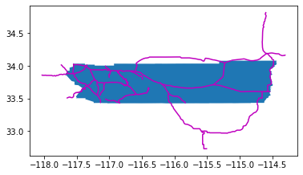

```python
ax = plt.gca()
rc_routes.plot(ax=ax,edgecolor='m')
county.plot(ax=ax)
plt.show()
```

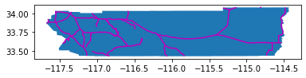

```python
ax = plt.gca()
rc_hw.plot(ax=ax,edgecolor='m')
county.plot(ax=ax)
plt.show()
```

Create CRS for rc_hw and set the crs to the same as the tracts

```python
rc_hw.crs = tracts_df.crs # create a crs for the rc_hw
rc_hw = rc_hw.to_crs(tracts_df.crs)
```

Now, create a new data frame that shows all the tracts that interect with a road We will then create another new data frame that will have true false values for whether or not there is a road intersecting it. We will then return to the old data frame, and make a collumn that will have 0 or 1 values for the intersection of a road.

```python
tracts_with_roads = gpd.sjoin(tracts_df, rc_hw, how='inner', op='intersects')

# Let's create an indicator (dummy) variable for use later
import numpy as np
geoids = tracts_df['GEOID10'].values
tract_hw = np.array([geoid in tracts_with_roads['GEOID10'].values for geoid in geoids])



tracts_df['intersectshw'] = tract_hw*1.
```

Next we will look at one particular city, and look at the roads that at some point intersect that city.

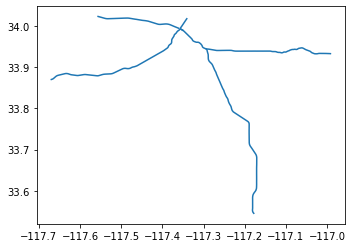

```python
#City
city = gpd.read_file('data/riverside_city.shp')



#Roads that intersect that city
r = routes_df['geometry']
r.apply(lambda x: x.intersects(city.iloc[0]['geometry']))
city_routes = r[r.apply(lambda x: x.intersects(city.iloc[0]['geometry']))]
city_routes.plot()
```

Okay, lets put it all together. The following map shows a lot of information, so stick with me.

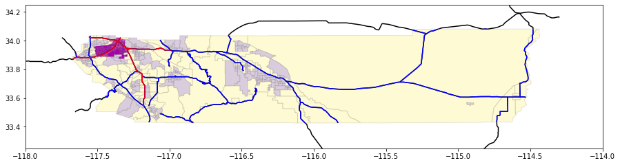

```python
#Setting figure size
plt.rcParams['figure.figsize'] = (15, 15)
#Setting an axis
ax = plt.gca()
#Roads that intersect with a tract but are outside the county boundaries
rc_routes.plot(ax=ax, edgecolor='k')
#Roads that intersect with a tract and stay within the county the whole time
rc_hw.plot(ax=ax, edgecolor='b')
#The city limits
city.plot(ax=ax, color="m")
#The county
tracts_df.plot(ax=ax, column='intersectshw',edgecolor='grey', alpha=0.2)
#Roads that go through the city
city_routes.plot(ax=ax, color="red")
#Setting the scale of the map
ax.set_xlim(-118.0, -114.0); ax.set_ylim(33.25, 34.25)
ax.set_aspect('equal')
plt.show()
```

Now, lets zoom in, and make the city a little bit clearler

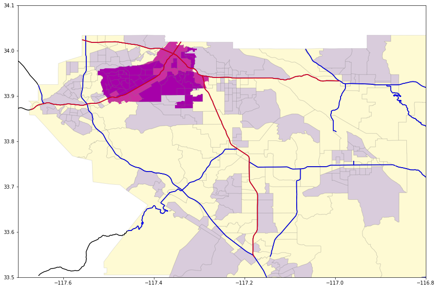

```python
plt.rcParams['figure.figsize'] = (15, 15)
ax = plt.gca()
rc_routes.plot(ax=ax, edgecolor='k')
rc_hw.plot(ax=ax, edgecolor='b')
city.plot(ax=ax, color="m")
tracts_df.plot(ax=ax, column='intersectshw',edgecolor='grey', alpha=0.2)
city_routes.plot(ax=ax, color="red")
ax.set_xlim(-117.7, -116.8); ax.set_ylim(33.5, 34.1)
ax.set_aspect('equal')
plt.show()
```

Now that we have done that, lets fous on geovisualization of data frames. First load in modules are read data

```python
import matplotlib.pyplot as plt # make plot larger
from pysal.viz import mapclassify
import geopandas as gpd
import matplotlib.pyplot as plt
import geopandas as gpd
shp_link = "data/texas.shp"
tx = gpd.read_file(shp_link)
```

Now I will show you a final visualization, that is quite complicated, but I will walk you through it

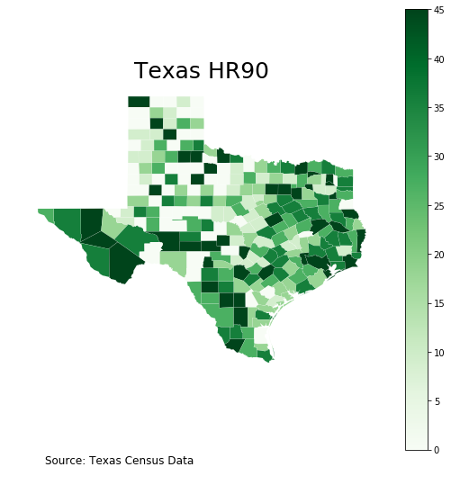

```python
variable= 'HR90'
vmin,vmax = 0,45
f, ax = plt.subplots(1, figsize=(9, 9))
tx.plot(column=variable, scheme='QUANTILES', \
        k=6, cmap='Greens', linewidth=0.1, ax=ax, \
        edgecolor='white', legend=False)

ax.set_axis_off()
ax.set_title("Texas HR90", fontdict={'fontsize': '25', 'fontweight' : '3'})
ax.annotate('Source: Texas Census Data',fontsize=12,xy=(0.1, .08), xycoords='figure fraction',
            horizontalalignment='left', verticalalignment='top')

sm = plt.cm.ScalarMappable(cmap='Greens', norm=plt.Normalize(vmin=vmin, vmax=vmax))
# empty array for the data range
sm._A = []
# add the colorbar to the figure
cbar = f.colorbar(sm)
```

The second part of the geovisualizations lab did not work for me, it simply did not run. I read through and undrerstand it relatively well, it just I cannot draw on it for my extension here.

I hope this lesson helps you a little bit with geovisualization and geocompuation! The information in this tutorial should help you find intersecting geometries, give you a solid basis with the .plot fuction to better visualize data, and give you a taste of what python can do.